# Git pre-install on Windows

Author

Ed123 Pal

## 1 Introduction

This tutorial is a precursor to the Git Install and Git Uninstall tutorials.

Using this tutorial, if you discover Git is currently installed on your computer, or was installed and then incompletely uninstalled in the past then see the Git Uninstall tutorial.

Proceed to the Git Install tutorial only when you are sure that Git or any Git remnants (from a prior install) are not present on your computer.

**Note**

In short, if you want to start using Git then you’ll want to have the latest copy of the Git software installed on your computer (see the Git Install tutorial). Using this pre-install tutorial, if you find that Git is currently installed or if there are any remnants from a prior install on your computer, you’ll want to remove them before installing the latest version of Git (see the Git Uninstall tutorial).

## 2 Learning Objectives

After completing this tutorial, you should be able to:

1. Determine if Git is installed on a computer.
2. Determine if there are any Git remnants on a computer.
3. Determine if Git is on the Path environment variable.
4. Explain where Git software, Git-related files and configurations are located.

## 3 Start Menu

This is what the Start menu looks like when Git is installed:

[figure not shown]

If Git is not installed on a computer, there will likely not be a Git folder on the Start menu.

## 4 Control Panel

### 4.1 Programs / Uninstall a program

This is what the Uninstall or change a program screen looks like if Git is installed:

[figure not shown]

If Git is not installed on a computer, there will likely not be a Git line on the Uninstall or change a program screen.

## 5 File System

### 5.1 Program Files

If Git is installed, the Git software will likely be stored in a folder named Git under the Program Files folder.

C:\Program Files\Git

This is the most likely location where you would find the Git folder.

### 5.2 Program Files (x86)

If Git is installed, the Git software could be stored in a folder named Git under the Program Files (x866) folder.

C:\Program Files (x86)\Git

### 5.3 C: drive root

If Git is installed, the Git software could be stored in a folder named Git on the root of the C drive.

## 6 where command

Using the where command in the Command Prompt window will display the location of the Git folder.

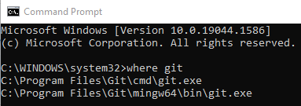

**Note**

It’s not likely, but you could encounter a situation where Git is installed, but the directory path to where the Git software is located might not be on the Path environment variable.

## 7 Path Variable

### 7.1 Find Git version

If Git is installed and if the location of the Git folder is stored on the Path environment variable then you should be able to find the Git version using the Command Prompt window as shown below:

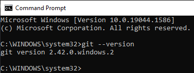

If Git is not installed then you’ll see the following:

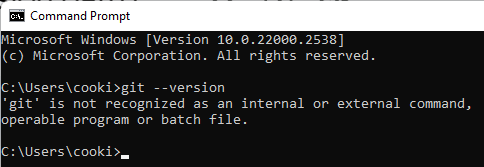

### 7.2 Examine Path

If Git is on the Path environment variable, it will likely look like this:

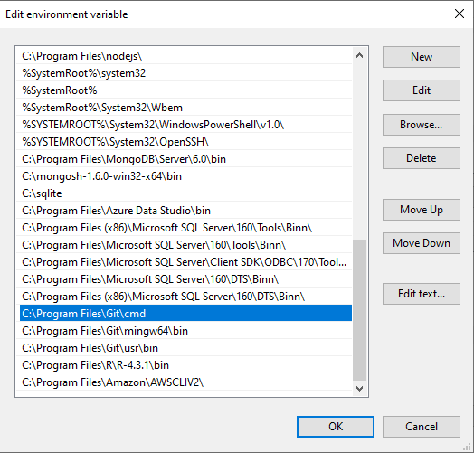

Click on this [link](https://www.c-sharpcorner.com/article/how-to-addedit-path-environment-variable-in-windows-11/) to learn how to find, examine and modify the Path variable on Windows 11.

## 8 Config Files

### 8.1 System config

The system config file controls settings for all users and all repositories on the computer unless it is overridden by an entry in the Global or Local config files.

The system configurartion file named gitconfig is located as follows:  
C:\Program Files\Git\etc\gitconfig

### 8.2 Global config

The global config file controls settings for the currently logged in user and all his repositories unless it is overridden by an entry in the Local config file.

The global configurartion file named .gitconfig is located as follows:  
C:\Users\username\.gitconfig (username is the name of user who is currently logged into the computer).

**Note**

Remember the . as the first character of a file name means the file is hidden so you’ll need to use the File Explorer View option to show Hidden items in order to locate the .gitconfig file.

## 9 Wrap up

### 9.1 Congratulations!

You’ve completed this tutorial and should now be able to identify if Git is installed on your computer and to identify if remnants from a prior install still exist on your computer.

If you find that Git is installed or if remnants exist then see the Git Uninstall tutorial before proceeding to the Git Install tutorial.